# Forest Fires

Andrei Petrisor, Antonio Radu, Lorenzo Medici, Andrea Rusconi

2023-12-01

## Forest fire

Questo dataset è pubblico e a disposizione per la ricerca. I dettagli sul dataset possono essere trovati in Cortez e Morais (2007). Il dataset è composto dalle seguenti variabili:

1. Coordinata spaziale dell’asse X all’interno della mappa del parco Montesinho: da 1 a 9
2. Y coordinata spaziale dell’asse y all’interno della mappa del parco Montesinho: da 2 a 9
3. mese: mese dell’anno: da “gen” a “dic”
4. giorno della settimana: da “lunedì” a “domenica”
5. Indice FFMC dal sistema FWI: da 18,7 a 96,20
6. Indice DMC dal sistema FWI: da 1,1 a 291,3
7. Indice DC dal sistema FWI: da 7,9 a 860,6
8. Indice ISI del sistema FWI: da 0,0 a 56,10
9. temperatura temporanea in gradi Celsius: da 2,2 a 33,30
10. Umidità relativa RH in %: da 15,0 a 100
11. velocità del vento in km/h: da 0,40 a 9,40
12. pioggia in mm/m2: da 0,0 a 6,4
13. area della superficie bruciata della foresta (in ettari): da 0,00 a 1090,84.

In questo dataset siamo interessati a modellare l’area bruciata della foresta come funzione delle altre variabili.

Cortez P. e Morais A. “Un approccio di data mining per prevedere gli incendi boschivi utilizzando dati meteorologici.” In J. Neves, MF Santos e J. Machado Eds., “Nuove tendenze nell’intelligenza artificiale”, Atti della 13a EPIA 2007 Conferenza portoghese sull’intelligenza artificiale, dicembre, Guimaraes, Por- tugal, pp. 512-523, 2007. APPIA, ISBN-13 978-989-95618-0-9. 18-0-9. Disponibile a: http://www3.dsi.uminho.pt/pcortez/fires.pdf

Punti 1-4 di come scrivere un buon report:

```
##  [1] "X"     "Y"     "month" "day"   "FFMC"  "DMC"   "DC"    "ISI"   "temp"
## [10] "RH"    "wind"  "rain"  "area"
```

```
##        X               Y          month               day
##  Min.   :1.000   Min.   :2.0   Length:517         Length:517
##  1st Qu.:3.000   1st Qu.:4.0   Class :character   Class :character
##  Median :4.000   Median :4.0   Mode  :character   Mode  :character
##  Mean   :4.669   Mean   :4.3
##  3rd Qu.:7.000   3rd Qu.:5.0
##  Max.   :9.000   Max.   :9.0
##       FFMC            DMC              DC             ISI
##  Min.   :18.70   Min.   :  1.1   Min.   :  7.9   Min.   : 0.000
##  1st Qu.:90.20   1st Qu.: 68.6   1st Qu.:437.7   1st Qu.: 6.500
##  Median :91.60   Median :108.3   Median :664.2   Median : 8.400
##  Mean   :90.64   Mean   :110.9   Mean   :547.9   Mean   : 9.022
##  3rd Qu.:92.90   3rd Qu.:142.4   3rd Qu.:713.9   3rd Qu.:10.800
##  Max.   :96.20   Max.   :291.3   Max.   :860.6   Max.   :56.100
##       temp             RH              wind            rain
##  Min.   : 2.20   Min.   : 15.00   Min.   :0.400   Min.   :0.00000
##  1st Qu.:15.50   1st Qu.: 33.00   1st Qu.:2.700   1st Qu.:0.00000
##  Median :19.30   Median : 42.00   Median :4.000   Median :0.00000
##  Mean   :18.89   Mean   : 44.29   Mean   :4.018   Mean   :0.02166
##  3rd Qu.:22.80   3rd Qu.: 53.00   3rd Qu.:4.900   3rd Qu.:0.00000
##  Max.   :33.30   Max.   :100.00   Max.   :9.400   Max.   :6.40000
##       area
##  Min.   :   0.00
##  1st Qu.:   0.00
##  Median :   0.52
##  Mean   :  12.85
##  3rd Qu.:   6.57
##  Max.   :1090.84
```

```
## [1] 0
```

```
##   month day FFMC  DMC    DC  ISI temp RH wind rain area
## 1   mar fri 86.2 26.2  94.3  5.1  8.2 51  6.7  0.0    0
## 2   oct tue 90.6 35.4 669.1  6.7 18.0 33  0.9  0.0    0
## 3   oct sat 90.6 43.7 686.9  6.7 14.6 33  1.3  0.0    0
## 4   mar fri 91.7 33.3  77.5  9.0  8.3 97  4.0  0.2    0
## 5   mar sun 89.3 51.3 102.2  9.6 11.4 99  1.8  0.0    0
## 6   aug sun 92.3 85.3 488.0 14.7 22.2 29  5.4  0.0    0
```

```
##      month      day          FFMC            DMC              DC
##  aug    :184   fri:85   Min.   :18.70   Min.   :  1.1   Min.   :  7.9
##  sep    :172   mon:74   1st Qu.:90.20   1st Qu.: 68.6   1st Qu.:437.7
##  mar    : 54   sat:84   Median :91.60   Median :108.3   Median :664.2
##  jul    : 32   sun:95   Mean   :90.64   Mean   :110.9   Mean   :547.9
##  feb    : 20   thu:61   3rd Qu.:92.90   3rd Qu.:142.4   3rd Qu.:713.9
##  jun    : 17   tue:64   Max.   :96.20   Max.   :291.3   Max.   :860.6
##  (Other): 38   wed:54
##       ISI              temp             RH              wind
##  Min.   : 0.000   Min.   : 2.20   Min.   : 15.00   Min.   :0.400
##  1st Qu.: 6.500   1st Qu.:15.50   1st Qu.: 33.00   1st Qu.:2.700
##  Median : 8.400   Median :19.30   Median : 42.00   Median :4.000
##  Mean   : 9.022   Mean   :18.89   Mean   : 44.29   Mean   :4.018
##  3rd Qu.:10.800   3rd Qu.:22.80   3rd Qu.: 53.00   3rd Qu.:4.900
##  Max.   :56.100   Max.   :33.30   Max.   :100.00   Max.   :9.400
##
##       rain              area
##  Min.   :0.00000   Min.   :   0.00
##  1st Qu.:0.00000   1st Qu.:   0.00
##  Median :0.00000   Median :   0.52
##  Mean   :0.02166   Mean   :  12.85
##  3rd Qu.:0.00000   3rd Qu.:   6.57
##  Max.   :6.40000   Max.   :1090.84
##
```

```
##
## apr aug dec feb jan jul jun mar may nov oct sep
##   9 184   9  20   2  32  17  54   2   1  15 172
```

```
##
## fri mon sat sun thu tue wed
##  85  74  84  95  61  64  54
```

```
##
##       fri mon sat sun thu tue wed
##   apr   1   1   1   3   2   0   1
##   aug  21  15  29  40  26  28  25
##   dec   1   4   0   1   1   1   1
##   feb   5   3   4   4   1   2   1
##   jan   0   0   1   1   0   0   0
##   jul   3   4   8   5   3   6   3
##   jun   3   3   2   4   2   0   3
##   mar  11  12  10   7   5   5   4
##   may   1   0   1   0   0   0   0
##   nov   0   0   0   0   0   1   0
##   oct   1   4   3   3   0   2   2
##   sep  38  28  25  27  21  19  14
```

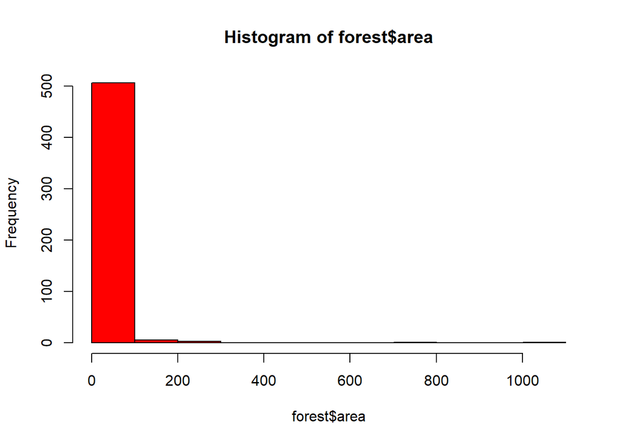

```
##    Min. 1st Qu.  Median    Mean 3rd Qu.    Max.
##    0.00    0.00    0.52   12.85    6.57 1090.84
```

```
## [1] 0.4777563
```

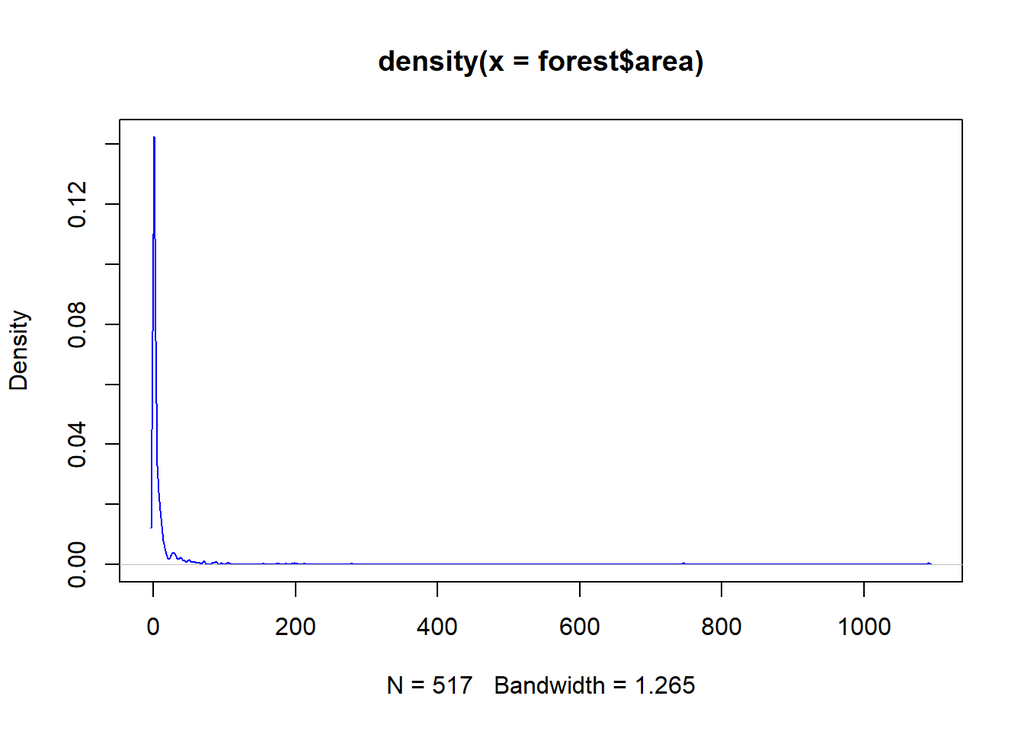

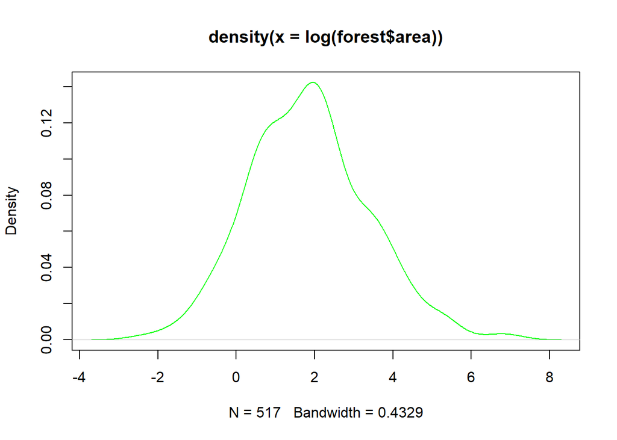

```
##    Min. 1st Qu.  Median    Mean 3rd Qu.    Max.
##  0.0000  0.0000  0.4187  1.1110  2.0242  6.9956
```

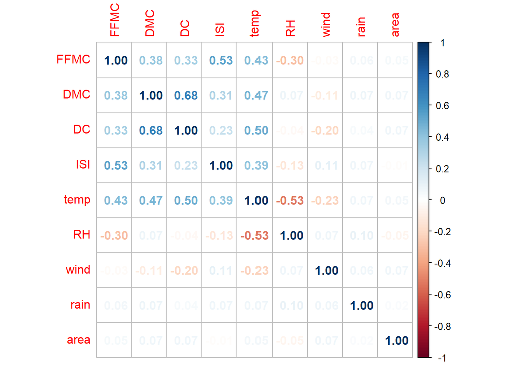

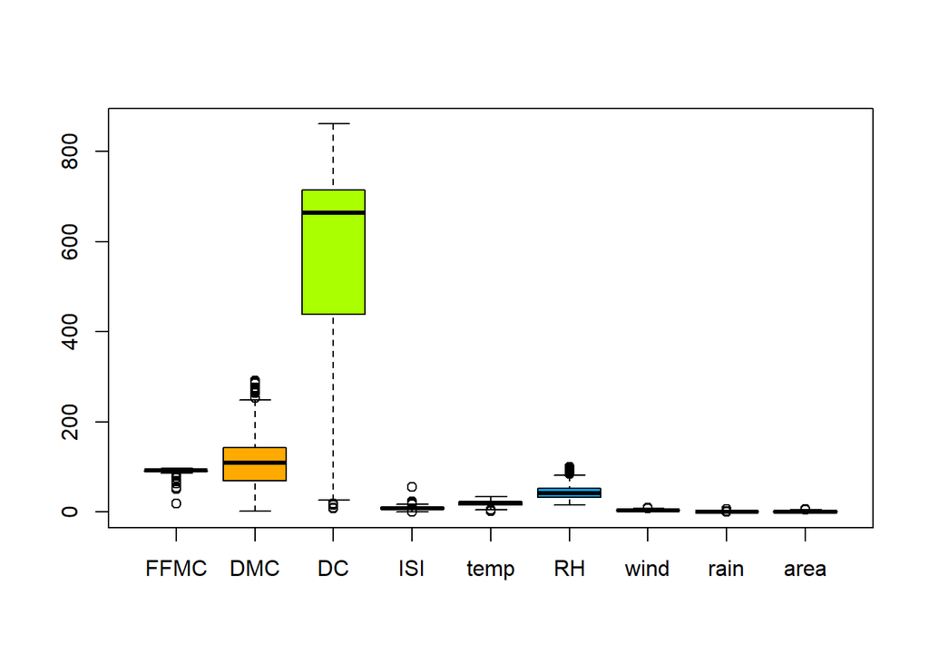

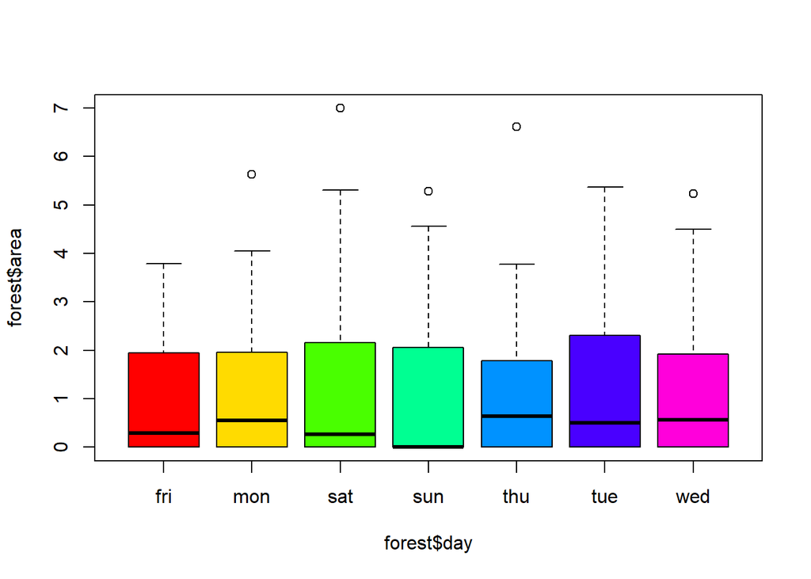

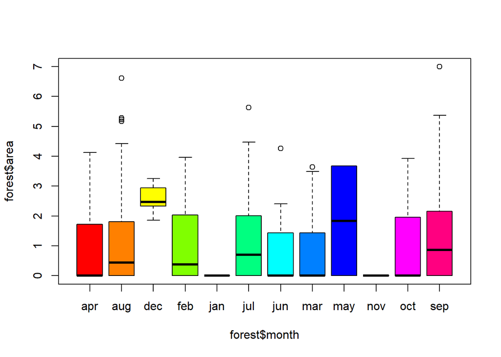

Potete prendere spunto da questo notebook: https://rstudio-pubs-static.s3.amazonaws.com/419751_b251adb1ab8e40f7aeab8b5c4a739c4f.html